# BCB420_Assignment2

Differential Gene expression and Preliminary ORA

Mingzheng liu

14/03/2022

## Objective of Assignment 2

To take the normalized expression data that was created in Assignment #1 and rank the genes according to differential expression. Once the gene list is ranked, a thresholded over-representation analysis is performed to highlight dominant themes in the top set of genes.

# Introduction

The dataset is derived from genetically engineered Foxd1Cre;Smo(flox/-) house mice and aims to investigate the mRNA content of mutant kidneys to gain a deeper understanding of the molecular mechanisms underlying the developmental defects observed in the kidney. The Hedgehog-GLI pathway, which is responsible for the development and patterning of various tissues and organs, including the kidney, interacts with the transforming growth factor beta (TGF) signaling pathway, another critical regulator of kidney development. Smo, a key component of the Hedgehog-GLI signaling pathway, plays a crucial role in human kidney development and modulates TGFβ signaling in the kidney, and its disruption can lead to abnormal kidney development and function. The ultimate goal of understanding the role of Smo in these signaling pathways is to uncover the molecular mechanisms underlying normal kidney development and diseases, which could ultimately lead to the development of new therapeutic strategies for kidney disorders.

In the previous work on the dataset with accession ID GSE103923, an initial processing of the data has been done, including accessing the dataset quality, filtering the low expression gene. The dataset was downloaded in a normalized data with identified as a mixed of HUGO symbol and he Mouse Genome Informatics (MGI) symbol. Hence, a identifier mapping was performed, and no extra normalization was applied. The result of assignment one is a a clean, normalized dataset stored in the root directory as “smo_exp_normalized.txt”.

## Preparation

Tools are needed for a differential expression analysis and a threshold over-representation analysis for our normalized dataset created in Assignment 1:

- Packages used

```r
if (!requireNamespace("BiocManager", quietly = TRUE))
  install.packages("BiocManager")
library(BiocManager)
if (!requireNamespace("GEOmetadb", quietly = TRUE))
  BiocManager::install("GEOmetadb")
library(GEOmetadb)
if (!requireNamespace("biomaRt", quietly = TRUE))
  BiocManager::install("biomaRt")
library(biomaRt)
if (!requireNamespace("edgeR", quietly = TRUE))
  BiocManager::install("edgeR")
library(edgeR)
if (!requireNamespace("circlize", quietly = TRUE))
    install.packages("circlize")
library(circlize)
if (!requireNamespace("ComplexHeatmap", quietly = TRUE))
    BiocManager::install("ComplexHeatmap")
library(ComplexHeatmap)
if (!requireNamespace("gprofiler2", quietly = TRUE))
    BiocManager::install("gprofiler2")
library(gprofiler2)
if (!requireNamespace("knitr", quietly = TRUE))
  install.packages("knitr")
library(knitr)
if (!requireNamespace("ggplot2", quietly = TRUE))
  install.packages("ggplot2")
library(ggplot2)
if (!requireNamespace("splines", quietly = TRUE))
  install.packages("splines")
library(splines)
if (!requireNamespace("GEOquery", quietly = TRUE))
  BiocManager::install("GEOquery")
library(GEOquery)
if (!requireNamespace("Biobase", quietly = TRUE))
  BiocManager::install("Biobase")
library(Biobase)
if (!requireNamespace("dplyr", quietly = TRUE))
  install.packages("dplyr")
library(dplyr)
if (!requireNamespace("kableExtra", quietly = TRUE)){
  install.packages("kableExtra")}
library(kableExtra)
```

## Prepare dataset from Assignment 1

```r
# Retreive the Assignment 1 result dataset
normalized_counts <- read.table("smo_exp_normalized.txt")
# Inspect the dataset
kable(normalized_counts[1:5,1:4], format = "html")
```

|  | MUT1 | MUT2 | MUT3 | MUT4 |
| --- | --- | --- | --- | --- |
| A2m | 8.594266 | 19.16863 | 8.961176 | 10.73999 |
| A4galt | 171.885312 | 128.85579 | 144.498960 | 128.87987 |
| Aaas | 543.348570 | 562.27980 | 541.030990 | 543.44347 |
| Aacs | 340.905869 | 363.13903 | 375.249237 | 379.12163 |
| Aagab | 550.987917 | 514.35822 | 567.914518 | 459.67155 |

```r
kable(normalized_counts[1:5,5:8], format = "html")
```

|  | WT1 | WT2 | WT3 | WT4 |
| --- | --- | --- | --- | --- |
| A2m | 8.506106 | 18.60708 | 11.62576 | 20.68402 |
| A4galt | 127.591595 | 138.51935 | 116.25760 | 131.62556 |
| Aaas | 507.814548 | 516.86324 | 516.37751 | 546.24606 |
| Aacs | 346.198528 | 350.43328 | 351.67924 | 331.88444 |
| Aagab | 495.055389 | 528.23424 | 450.49820 | 448.46708 |

# Differential Gene Expression

Two steps will be performed in this step: * Step 1: Create a design model to be used for calculating differential expression, * Step 2: Perform an analysis of differential expression using the normalized expression data obtained in A1.

## Step 1: Create a design matrix

- This dataset has only one factor, the Smo knockout mutant type.
- The control will be the wild-type samples.
- inspect our dataset and refer back to the MDS plot from A1 to show which factors included in my model.

```r
# Calculate distances and plot MDS
dist <- dist(t(log2(cpm(normalized_counts) + 1)))
plotMDS(dist,
        labels=colnames(normalized_counts),
        col=ifelse(grepl("WT",colnames(normalized_counts)), "#00FFFF", "#FF00BF"),
        pch=16, main="Normalized MDS plot of Smo(flox/-) mutants and wild type")
```

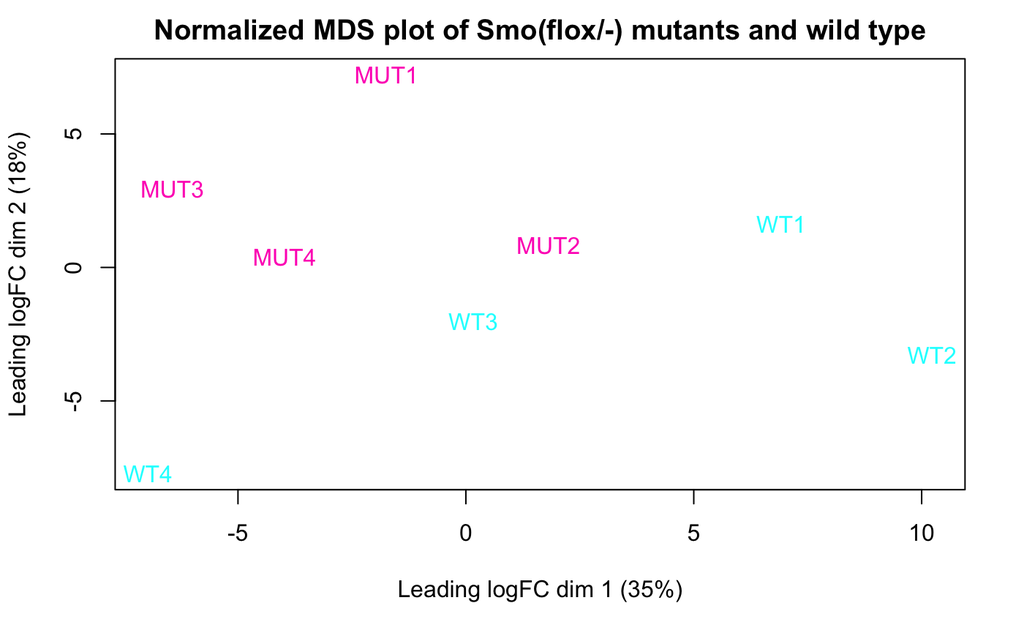

### Create design matrix with genotype factor

- use a linear model.
- The genotype factor represents the two different types of samples (Smo-knockout and wild type).

```r
# define the groups
samples <- data.frame(
  lapply(colnames(normalized_counts), FUN=function(x) {
    if (grepl("MUT", x)) {
      # If the column name contains "MUT", extract the characters following "MUT"
      "MUT"
    } else if (grepl("WT", x)) {
      # If the column name contains "WT", extract the characters following "WT"
      "WT"
    }
  })
)
# set row and column names
colnames(samples) <- colnames(normalized_counts)
rownames(samples) <- c("genotype")
samples <- data.frame(t(samples))
#inspect
samples[1:8,]
```

```
[1] "MUT" "MUT" "MUT" "MUT" "WT"  "WT"  "WT"  "WT"
```

```r
# create a design matrix of a linear model
design <- model.matrix(~ samples$genotype)
# inspect
kable(design[2:7,], type ="html")
```

|  | (Intercept) | samples$genotypeWT |
| --- | --- | --- |
| 2 | 1 | 0 |
| 3 | 1 | 0 |
| 4 | 1 | 0 |
| 5 | 1 | 1 |
| 6 | 1 | 1 |
| 7 | 1 | 1 |

### Check assumption

- perform diagnostic Mean-Variance plot for our dataset
- Verify the assumption that our dataset to be negative-binomially distributed to use a linear model

```r
# create a DGEList object
dge <- DGEList(counts = normalized_counts, group = factor(rep(c("MUT", "WT"), each = 4)))

# filter low-expressed genes
keep <- rowSums(cpm(dge) > 1) >= 2
dge <- dge[keep,]

# normalize data
dge <- calcNormFactors(dge)

# estimate dispersion
dge <- estimateDisp(dge)

# estimate tagwise dispersion
tagwise_disp <- estimateTagwiseDisp(dge)

# generate MV plot
plotMeanVar(dge,
            show.raw.vars = TRUE,
            show.tagwise.vars = TRUE,
            NBline = TRUE,
            show.ave.raw.vars = TRUE,
            show.binned.common.disp.vars = TRUE,
            main = "Mean-Variance Plot of Smo(flox/-) mutants and wild type")
# add legend
legend("topleft",
       legend=c("Raw Data", "Tagwise Dispersion", "Average Raw Variances",
                "Binned Common Dispersion", "Negative Binomial Line"),
       col = c("grey", "lightblue", "maroon", "red", "dodgerblue2"),
       pch=c(1,1,4,4,NA), lty=c(0,0,0,0,1), lwd=c(1,1,1,1,2), cex=0.6)
```

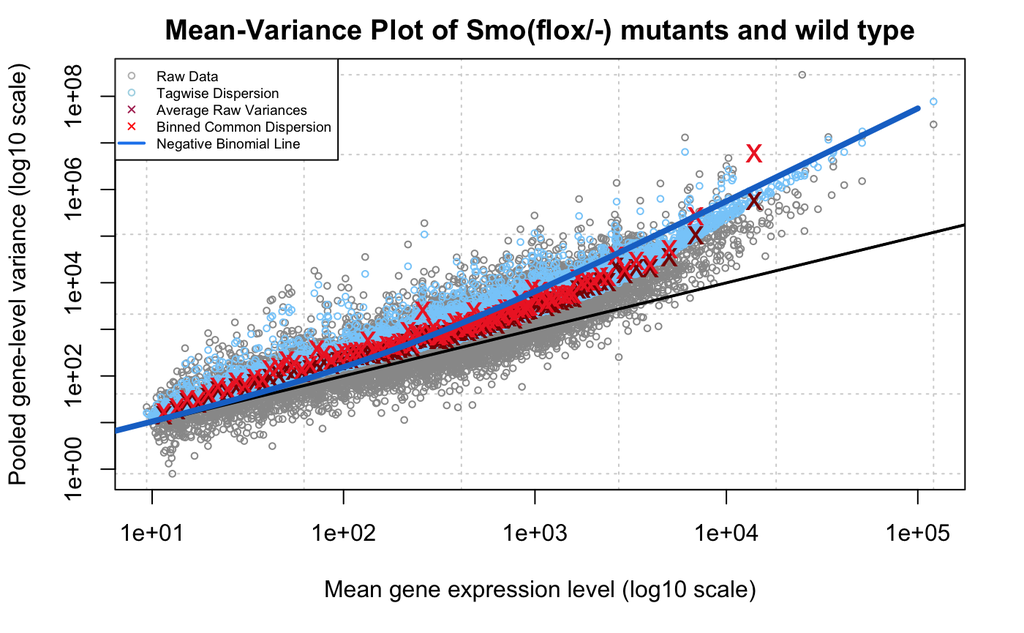

## Step 2: Differential Expression Analysis

1. Calculate p-values for each of the genes in your expression set. How many genes were significantly differentially expressed? What thresholds did you use and why?

```r
# create a matrix
expressionMatrix <- as.matrix(normalized_counts[,1:8])
# Set row and column names
rownames(expressionMatrix) <- rownames(normalized_counts)
colnames(expressionMatrix) <- colnames(normalized_counts)[1:8]
# Create a minimal ExpressionSet object to use with limma
minimalSet <- ExpressionSet(assayData=expressionMatrix)

# Fit a linear model
fit <- lmFit(minimalSet, design)

# Use eBayes to estimate the posterior distribution of log-fold changes
# and calculate moderated t-statistics for each gene
fit2 <- eBayes(fit, robust = T)

# Get the top differentially expressed genes
top_genes <- topTable(fit2,
                   coef=ncol(design),
                   adjust.method = "BH",
                   number = nrow(expressionMatrix))
```

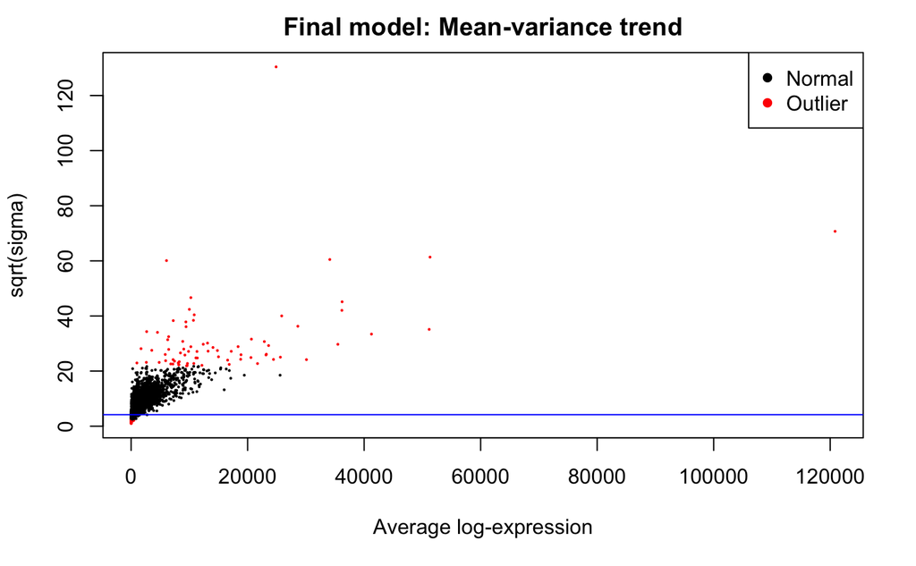

```r
plotSA(fit2, main="Final model: Mean-variance trend")
```

```r
# merge gene ids to topfit table
output_hits <- merge(rownames(normalized_counts),
                     top_genes,
                     by.y=0,by.x=1,
                     all.y=TRUE)
# sort by p-value
output_hits <- output_hits[order(output_hits$P.Value),]

# inspect
kable(output_hits[1:5,1:7],type="html",row.names = FALSE)
# Rename the column name of gene
colnames(output_hits)[1] <- "gene"

# calculate the number of gene pass the threshold p-value < 0.05
length(which(output_hits$P.Value < 0.05))
```

[output not shown]

- We can observe that 1027 genes pass the threshold p-value < 0.05.
- A threshold of p-value < 0.05 is used to determine significant differential expression. This is a commonly used threshold in statistical analysis, as it indicates that there is less than a 5% chance that the observed differences in gene expression are due to random chance.
2. Multiple hypothesis testing - correct your p-values using a multiple hypothesis correction method. Which method did you use? And Why? How many genes passed correction?

```r
# How many genes pass correction (multipole hypothesis testing) ?
length(which(output_hits$adj.P.Val < 0.05))
```

[output not shown]

- The choice of multiple hypothesis testing method will be the Benjamini-Hochberg method to controls the false discovery rate (FDR) given that it the gene expression data of the whole cell and genes are independent or weakly correlated.Benjamini-Hochberg method are appropriate for controlling the FDR in large-scale hypothesis testing.
- 49 genes passed this correction.
3. Show the amount of differentially expressed genes using an MA Plot or a Volcano plot. Highlight genes of interest.
- Volcano Plot is used for visualization. The genes of interest with a high log fold change values are labeled in blue.

```r
# Create a vector of colors for each point in the volcano plot
colors <- ifelse(output_hits$P.Value < 0.05 & output_hits$logFC > 1, "red",
         ifelse(output_hits$P.Value < 0.05 & output_hits$logFC < -1, "green", "grey"))

# Plot the volcano plot with colored points
plot(output_hits$logFC, -log10(output_hits$P.Value), pch=20, col=colors,
     xlab="log2(Fold Change)", ylab="-log10(P-value)",
     main="Volcano Plot of Smo(flox/-) mutants and wild type")

# Add legend for the colors
legend("topright", legend=c("Up-regulated", "Down-regulated", "Non-significant"),
       col=c("red", "green", "grey"), pch=20, cex=0.8)

# Label genes with over top 10 logFC
# Subset top 10 genes with largest absolute logFC values
top10_genes <- subset(output_hits,
                      abs(logFC) > sort(abs(logFC), decreasing = TRUE)[10])

# Add text labels to the top 10 logFC points in volcano plot
with(output_hits, {
  text(x = logFC,
       y = -log10(P.Value),
       labels = ifelse(gene %in% top10_genes$gene, gene, ""),
       pos = 4, cex = 0.5, srt=45, col="blue")
})
```

[output not shown]

4. Visualize your top hits using a heatmap. Do you conditions cluster together? Explain why or why not.
- To find the most significantly differentially expressed, we select the genes that pass a P-value threshold of 0.05, and has absolute value of LFC larger than 2 as the top hits.

```r
# Get top hit genes based on p-value and log fold change
top_hits <- output_hits$gene[output_hits$P.Value < 0.05 & abs(output_hits$logFC) > 2]

# Calculate logCPM values for all genes
hm_matrix <- log2(normalized_counts + 1) # Add 1 to avoid log transformation of zero counts.

# Subset matrix to include only top hit genes
heatmap_matrix_tophits <- t(scale(
    t(hm_matrix[which(rownames(hm_matrix) %in% top_hits),]),
    center = TRUE, scale = TRUE))

# Choose colors for heatmap
heatmap_color <- colorRamp2(c(min(heatmap_matrix_tophits), 0, max(heatmap_matrix_tophits)),
                            c("#00FFFF", "white", "#FF00BF"))

# Create heatmap with dendrograms for genes and samples
current_heatmap <- Heatmap(as.matrix(heatmap_matrix_tophits),
                           show_row_dend = TRUE,
                           show_column_dend = TRUE,
                           col = heatmap_color,
                           show_column_names = TRUE,
                           show_row_names = FALSE,
                           show_heatmap_legend = TRUE,
                           column_names_gp = grid::gpar(fontsize = 6),
                           heatmap_legend_param = list(title = "Expression level"))
draw(current_heatmap,
   column_title=
     "Gene expression between Smo(flox/-) mutants (MUT) and wild type (WT) ",
   column_title_gp=grid::gpar(fontsize=12))
```

[output not shown]

- The heatmap does has a clear clustering of gene expression values that are either up-regulated genes or the down-regulated genes, which suggests a evidence of differentially expressed genes.

# Thresholded over-representation analysis

Run a thresholded gene set enrichment analysis (GSEA) with your significantly up-regulated and down-regulated set of genes using the g:Profiler.

## Preparation of up-regulated and down-regulated

```r
# Create a vector of gene symbols for the up-regulated and down-regulated genes
upregulated <- output_hits[output_hits$logFC > 0 & output_hits$P.Value < 0.05, ]
downregulated <- output_hits[output_hits$logFC < 0 & output_hits$P.Value < 0.05, ]

upregulated_genes <- upregulated$gene
downregulated_genes <- downregulated$gene
```

## Perform gene set enrichment analysis

- Use the gprofiler2 function to perform gene set enrichment analysis
- Note that we were using the organism = mmusculus instead of hsapiens, given that the gene data is collected from house mice

```r
# analyze for all differentially expressed genes
enrich <- gost(query = output_hits$gene, organism = "mmusculus",
                           ordered_query = TRUE,
                     measure_underrepresentation = TRUE,
                     correction_method = "fdr",
                     sources = c("GO:BP", "REAC", "WP"))
# analyze for up-regulated differentially expressed genes
enrich_upreg <- gost(query = upregulated_genes, organism = "mmusculus",
                           ordered_query = TRUE,
                     measure_underrepresentation = TRUE,
                     correction_method = "fdr",
                     sources = c("GO:BP", "REAC", "WP"))
# analyze for down-regulated differentially expressed genes
enrich_downreg <- gost(downregulated_genes, organism = "mmusculus",
                           ordered_query = TRUE,
                     measure_underrepresentation = TRUE,
                     correction_method = "fdr",
                     sources = c("GO:BP", "REAC", "WP"))
```

```r
# extract the enriched gene sets with a p-value < 0.05
enriched <- enrich$result[enrich$result$p_value < 0.05, ]
enriched_upreg <- enrich_upreg$result[enrich_upreg$result$p_value < 0.05, ]
enriched_downreg <- enrich_downreg$result[enrich_downreg$result$p_value < 0.05, ]
```

```r
# inspect top 5
knitr::kable(head(enriched[,3:11], 5), format = "html",
             table.attr = 'style="width: 30%; border-collapse: separate; border-spacing: 15px;"')
knitr::kable(head(enriched_upreg[,3:11], 5), format = "html",
             table.attr = 'style="width: 30%; border-collapse: separate; border-spacing: 15px;"')
knitr::kable(head(enriched_downreg[,3:11], 5), format = "html",
             table.attr = 'style="width: 30%; border-collapse: separate; border-spacing: 15px;"')
```

[output not shown]

```r
# inspect top one from three data sources for all genes
knitr::kable(rbind(enriched[enriched$source == "GO:BP",][1,9:13],
                   enriched[enriched$source == "REAC",][1,9:13],
                   enriched[enriched$source == "WP",][1,9:13]),
             format = "html",
             table.attr = 'style="width: 30%; border-collapse: separate; border-spacing: 15px;"')

# inspect top one from three data sources for up-regulated genes
knitr::kable(rbind(enriched_upreg[enriched_upreg$source == "GO:BP",][1,9:13],
                   enriched_upreg[enriched_upreg$source == "REAC",][1,9:13],
                   enriched_upreg[enriched_upreg$source == "WP",][1,9:13]),
             format = "html",
             table.attr = 'style="width: 30%; border-collapse: separate; border-spacing: 15px;"')

# inspect top one from three data sources for down-regulated genes
knitr::kable(rbind(enriched_downreg[enriched_downreg$source == "GO:BP",][1,9:13],
                   enriched_downreg[enriched_downreg$source == "REAC",][1,9:13],
                   enriched_downreg[enriched_downreg$source == "WP",][1,9:13]),
             format = "html",
             table.attr = 'style="width: 30%; border-collapse: separate; border-spacing: 15px;"')
```

[output not shown]

The top term returned in each data source for all genes: * GO:BP: biological_process * REAC: Classical antibody-mediated complement activation * WP: Fatty acid omega-oxidation

The top term returned in each data source for both up- and down-regulated genes: * GO:BP: biological_process * REAC: REACTOME root term  
* WP: WIKIPATHWAYS

## Visual Representation of the GSEA results

```r
# Three interative figures were generate by g:profiler::gostplot
# Generate a Manhattan plot to visualize the distribution of the top genesets from each data source.
gostplot(enrich) %>% plotly::layout(title = "Manhattan plot for genes", font = list(size = 10))
# Generate a Manhattan plot to visualize the distribution of the top genesets from each data source.
gostplot(enrich_upreg) %>% plotly::layout(title = "Manhattan plot for Upregulated genes", font = list(size = 10))
# Generate a Manhattan plot to visualize the distribution of the top genesets from each data source.
gostplot(enrich_downreg) %>% plotly::layout(title = "Manhattan plot for Downregulated genes", font = list(size = 10))
```

[output not shown]